# Vectorization in R

#### Preliminary Explanation

First of all, there is a common consensus among coders is that premature optimization is the root of all evil [Knuth](http://wiki.c2.com/?PrematureOptimization). In other words, we should not start re-writing our code unless the time saved is going to be worth the time invested. GPU’s, parallel programming, even FPGA’s can give us more lift in terms of programming time.But if you understand the nuts and bolts of vectorization in R, it may help you write shorter, simpler, safer, and yes, faster code in the first place.

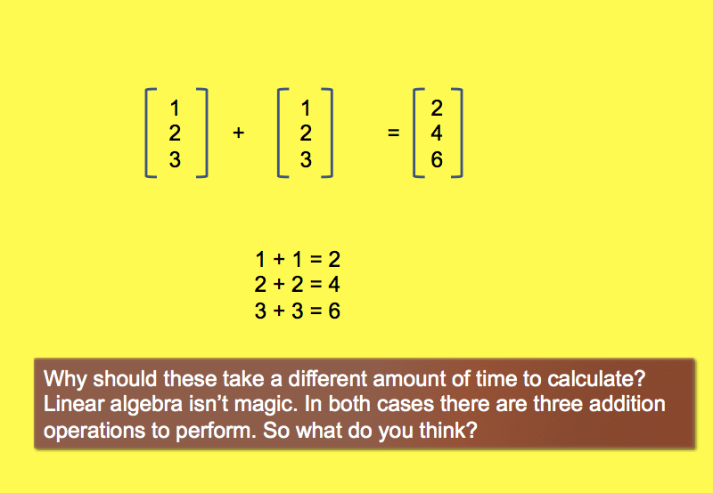

In R, a “vector” refers to a one-dimensional array. A “vectorized” function f() takes a vector [x1, x2, … , xn] as input and returns the vector [f(x1), f(x2), f(x3), … , f(xn)].

R is a high-level, *interpreted* computer language. This means that R takes care of a lot of basic computer tasks for you. For instance, when you type

```
x <- 4.0
```

We don’t have to tell our computer:

- That “4.0” is a floating-point number
- That “x” should store numeric-type data
- To find a place in memory for to put “4”
- To register “x” as a pointer to that place in memory

We also don’t have to convert x <- 4.0 to binary code. That’s done automatically when you hit ‘Enter’.

When we type

```
x<-"Programming for Analytics"
```

R figures these things on the fly, as you type commands or source them from a file. This means that running a command in R takes a relatively longer time than it might in a lower-level language, such as C. If I am writing in C, I might write

```
int x

x = 4
```

This tells the computer the x will store data of the type int (integers), and assign the value 4 to it. If I try to assign 4.5 to it, something will go wrong. Depending on my set-up, it might throw an error, or just silently assign 4 to x. But C doesn’t have to figure out what type of data is is represented by x and this is part of what makes it faster.

Here’s another example. If, in R, you type:

```
2 + 4.5
```

- From bottom to up computer asks:
  - “OK, what’s the first thing?”
  - “An integer”
  - “The second thing?”
  - “A a floating-point number”
  - “Do we have a way to deal with adding an integer and a floating-point number?”
  - “Yes! Convert the integer to a floating-point number, then add the two floating point numbers”
  - [converts integer]
  - [finds a place in memory for the answer]
  - etc.

If R were a compiled computer language, like C or FORTRAN, much of this “figuring out” would be achieved during the compilation step, not when the program was run. Compiled programs are translated into binary computer language after they are written, but before they are run, and this occurs over the whole program, rather than line-by-line. This allows the compiler to organize the binary machine code in an optimal way for the computer to interpret.

What does this have to do with vectorization in R? Well, many R functions are actually written in a a compiled language, such as C, C++, and FORTRAN, and have a small R “wrapper”. For instance, when you inspect the code for fft, the fast Fourier transform, you see

```r
fft
```

```
## function (z, inverse = FALSE)
## .Call(C_fft, z, inverse)
## <bytecode: 0x7ffc69283790>
## <environment: namespace:stats>
```

R is passing the data onto a C function called C_fft. You’ll see this in many R functions. If you look at their source code, it will include .C(), .Call(), or sometimes .Internal() or .Primitive(). These means R is calling a C, C++, or FORTRAN program to carry out operations. However, R still has to interpret the input of the function before passing it to the compiled code. In fft() the compiled code runs only after R figures out the data type in z, and also whether to use the default value of inverse. The compiled code is able to run faster than code written in pure R, because the “figuring out” stuff is done first, and it can zoom ahead without the “translation” steps that R needs.

If you need to run a function over all the values in a vector, you could pass a whole vector through the R function to the compiled code, or you could call the R function repeatedly for each value. If you do the latter, R has to do the “figuring out” stuff, as well as the translation, each time. But if you call it once, with a vector, the “figuring out” part happens just once.

Another important component of the speed of vectorized operations is that vectors in R are typed. Despite all of its flexibility, R does have some restrictions on what we can do. All elements of a vector must be the same data type. If I try to do this

```r
PfA<-c(1,2,FALSE,"programming for analytics")

PfA
```

```
## [1] "1"                         "2"
## [3] "FALSE"                     "programming for analytics"
```

```r
class(PfA)
```

```
## [1] "character"
```

R converts alldata to characters. It can’t handle a vector with different data types.

```
c(1,2,3,4,5,6) + c(2,4,6,8,10,12)
```

R only asks what types of data are in each vector rather than each element (2 vs 12)

In brief, fast R code is short. If you can express what you want to do in R in a line or two, with just a few function calls that are actually calling compiled code, it’ll be more efficient than if you write long program, with the added overhead of many function calls. This is not the case in all other languages. Often, in compiled languages, you want to stick with lots of very simple statements, because that allows the compiler to figure out the most efficient translation of the code.

*“All naked numbers are double-width floating-point atomic vectors of length one. You are welcome.”*

*Tim Smith*

So, while in other languages, it might be more efficient to express something as a single number rather than a length-one vector, in R this is impossible. There’s no advantage to NOT organizing your data as vector.

##### Apply Family and Memory Allocation

```r
j <- 1
for (i in 1:10) {
    j[i] = 10
}
```

The apply functions all actually have for loops inside, but they automatically do things like pre-allocating vector size so you don’t screw it up. This is the main reason that they can be faster.

Another thing that “apply” functions help with is avoiding what are known as side effects. When you run a apply function, everything happens inside that function, and nothing changes in your working environment (this is known as *“functional programming”)*. In a for loop, on the other hand, when you do something like for(i in 1:10), you get the leftover i in your environment. This is considered bad practice sometimes. Having a bunch of temporary variables like i lying around could cause problems in your code, especially if you use i for something else later.

Once you are used to writing vectorized code in general, though, for loops in R will can seem odd.

$\color{red}{\text{--- NOW We will take a look at APPLY Functions in detail to continue reading below this part--- }}$,

### Why Vectorization is Important?

The idea that one should avoid loops wherever possible in R, using instead vectorized functions (which compensates (somewhat) for this weakness by using vectorized functions!) like those in the apply family, is quite widespread in some quarters (Ligges & Fox, 2008). The proposition is that loops are very slow in R. Vectorized functions usually involve a behind-the-scenes loop in a low-level language (C or Fortran), which runs way faster than a pure R loop. Here’s an example using the log() function that illustrates the speedup you can get by exploiting the fact that log() is vectorized.

Let’s have a critical look at this.

```r
# illustrating log's behavior: single values and vectors
log(3)
```

```
## [1] 1.098612
```

```r
log(1:10)
```

```
##  [1] 0.0000000 0.6931472 1.0986123 1.3862944 1.6094379 1.7917595 1.9459101
##  [8] 2.0794415 2.1972246 2.3025851
```

```r
# a vector of 1 million random numbers between 1 and 10
nums = sample(1:10, size=1e6, replace=TRUE)

# my function to call log on each vector element separately:
log_novec = function(n){
   ret = numeric(length(n))
   for(i in seq_along(n)){
     ret[i] = log(n[i])
   }
   return(ret)
 }
```

```r
# timing results:
system.time(log_novec(nums))
```

```
##    user  system elapsed
##   0.253   0.003   0.256
```

```r
system.time(log(nums))
```

```
##    user  system elapsed
##   0.021   0.000   0.021
```

wow, 10x speedup! So in conclusion: vectorization is important because it allows you to operate on vectors quickly (unlike looping)

#### Quick Noted for R Coders

If you are acting as an R user, you don’t need to worry about WRITING vectorized functions. But if you’d like to write R code that will run in a reasonable amount of time on large dataset (memory issues aside), it’s good to think about USING vectorized functions, which consequently means learning where and when to look for them. If, on the other hand, you are acting as an R developer, you might have to implement your own vectorized function, which will probably involve writing some C or Fortan.

#### Implications for Apply() Family

```r
system.time(sapply(nums, log))
```

```
##    user  system elapsed
##   1.055   0.028   1.086
```

[output not shown]

#### Practice

1. Write a code that will iterate over a vector has 1 million elements (range from 0 to 2 times pi) and returns sin(x) values after each iteration.

To time this, we can wrap the vectorizable parts in a call to system.time:

[output not shown]

We can compare this with a simple call to sin (which is vectorized):

```r
system.time(z <- sin(x))
```

```
##    user  system elapsed
##   0.027   0.000   0.027
```

Compare the time spent on the equivalent calculation, using sapply. What does this result tell you about where the computational cost is incurred?

[output not shown]

The above example is very simple in that there is a builtin function (sin in this case) which is capable of the fully vectorized computation. In such a case, it is clearly preferable to use it. Frequently, however, no such builtin function exists, i.e., we have a custom function of our own we want to apply to a set of data. Let’s compare the relative speeds of loops and sapply in this case.

```r
x <- seq.int(20,1e6,10)
f <- function (x) {
  (((x+1)*x+1)*x+1)*x+1
}
system.time({
  res1 <- numeric(length(x))
  for (k in seq_along(x)) {
    res1[k] <- f(x[k])
  }
})
```

```
##    user  system elapsed
##   0.124   0.000   0.125
```

```r
system.time(res2 <- sapply(x,f))
```

```
##    user  system elapsed
##   0.124   0.001   0.125
```

```r
system.time(f(x))
```

```
##    user  system elapsed
##   0.002   0.000   0.002
```

```r
g <- function (x) {
  if ((x[1] > 30) && (x[1] < 5000)) 1 else 0
}

system.time({
  res1 <- numeric(length(x))
  for (k in seq_along(x)) {
    res1[k] <- g(x[k])
  }
})
```

```
##    user  system elapsed
##   0.127   0.000   0.127
```

```r
system.time(res2 <- sapply(x,g))
```

```
##    user  system elapsed
##   0.118   0.000   0.118
```